# CEE118X_HW4

Bill Li

10/15/2021

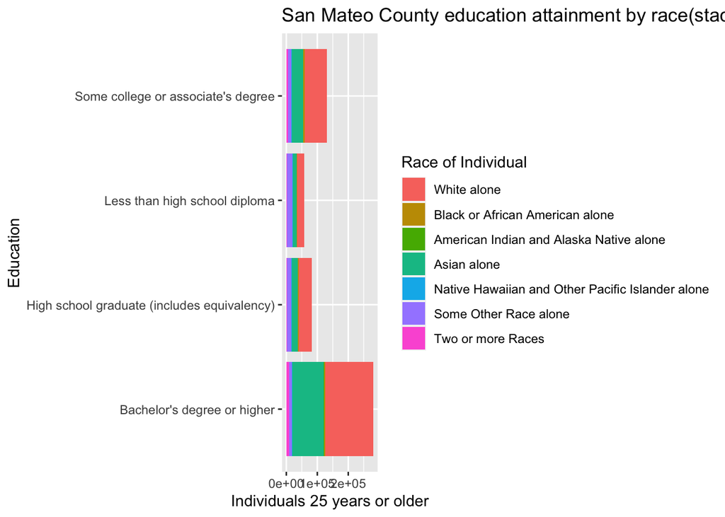

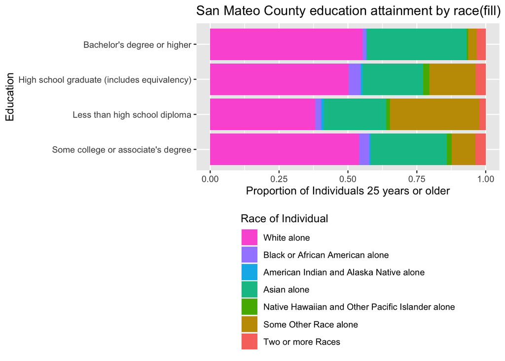

“Is there disproportionate education attainment by race in the county?” Answer: Based on the data from San Mateo County, there is a disproportionate education attainment by race for individuals 25 years or older. In white race population, there is a significant more proportion of individuals that have some college or bachelor’s degree than lss than high school diploma. When you compare white alone to black or African American alone, there is a disproportionate education attainment. The proportion of black individuals holding bachelor’s degree or higher is far less than high school graduate. The situation is the opposite in white individuals. American Indian and Alaska Native alone does not face disproportionate education attainment. In Asian alone population, there is a greater proportion of individuals that have bachelor’s degree or higher than the three other educational categories.

casewhen function !!!!!

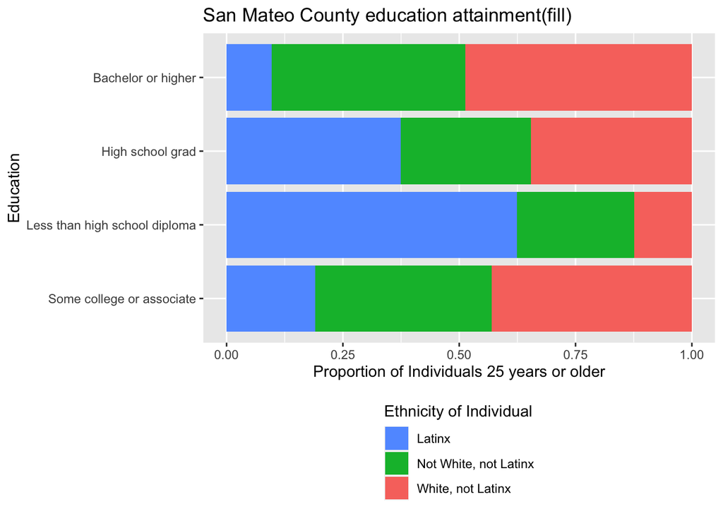

Answer: From the analysis above, we can see that Latinx population experienced a disproportionate education attainment comparing to White population. Latinx constitutes a majority of Less than high schoool diploma whereas White, not Latinx constitutes a majority of Bachelor or higher. High school graduates proportion among the three ethnicity groups are relatively equal. There is still noticeable difference between in Some college or associate category between Latinx and White, not Latinx. There is a greater proportion of white, not Latinx that hold some college or associate degree than latinx.